# R Notebook

# Model Building

MVP

We’ve looked at a few different ways in which we can build models this week, including how to prepare them properly. This weekend we’ll build a multiple linear regression model on a dataset which will need some preparation. The data can be found in the data folder, along with a data dictionary

We want to investigate the avocado dataset, and, in particular, to model the *AveragePrice* of the avocados. Use the tools we’ve worked with this week in order to prepare your dataset and find appropriate predictors. Once you’ve built your model use the validation techniques discussed on Wednesday to evaluate it. Feel free to focus either on building an explanatory or a predictive model, or both if you are feeling energetic!

As part of the MVP we want you not to just run the code but also have a go at *interpreting the results* and write your thinking in comments in your script.

Hints and tips

region may lead to many dummy variables. Think carefully about whether to include this variable or not (there is no one ‘right’ answer to this!) Think about whether each variable is categorical or numerical. If categorical, make sure that the variable is represented as a factor. We will not treat this data as a time series, so Date will not be needed in your models, but can you extract any useful features out of Date before you discard it? If you want to build a predictive model, consider using either leaps or glmulti to help with this.

index Date: The date of the observation AveragePrice: the average price of a single avocado Total Volume: Total number of avocados sold 4046: Total number of avocados with PLU 4046 sold 4225: Total number of avocados with PLU 4225 sold 4770: Total number of avocados with PLU 4770 sold Total Bags Small Bags Large Bags XLarge Bags type: conventional or organic year: the year region: the city or region of the observation

### What is it PLU?

Product Lookup code (PLU) Small/Medium Hass Avocado (~3-5oz avocado) | #4046 Large Hass Avocado (~8-10oz avocado) | #4225 Extra Large Hass Avocado (~10-15oz avocado) | #4770

```r
library(tidyverse)
library(fastDummies)
library(GGally)
library(ggfortify)
library(modelr)
library(janitor)
library(lubridate)
library(leaps)
library(broom)
```

```r
avocado <- read_csv("data/avocado.csv") %>% clean_names()

glimpse(avocado)
```

[output not shown]

```r
# check for missing values - all good!
avocado %>%
  summarise(across(.fns = ~ sum(is.na(.x))))
```

| x1 | date | average_price | total_volume | x4046 | x4225 | x4770 | total_bags | small_bags | large_bags | x_large_bags | type | year | region |
| --- | --- | --- | --- | --- | --- | --- | --- | --- | --- | --- | --- | --- | --- |
| 0 | 0 | 0 | 0 | 0 | 0 | 0 | 0 | 0 | 0 | 0 | 0 | 0 | 0 |

### Split data into training and testing data sets (80/20)

```r
# get the number of observations (rows)
n_data <- nrow(avocado)

# set seed to make my partition reproducible
set.seed(123)

# get random observations (rows) to ensure I have a good distribution in my data set
test_index <- sample(1:n_data, size = n_data * 0.2)

test <- slice(avocado, test_index)
train <- slice(avocado, -test_index)
```

```r
# tidy the data set
## extract months from variable `date` as it might potentially show some interesting patterns,
## get rid of unnecessary or redundant variables,
## change PLU codes to actual size for easier readability,
## change all categorical variables to factor
avocado_tidy <- train %>%
  mutate(
    month = month(date)
  ) %>%
  select(-c("x1", "date", "small_bags", "large_bags", "x_large_bags", "region")) %>%
  rename(size_SM = x4046,
         size_L = x4225,
         size_XL = x4770) %>%
  mutate(
    #total_volume = round(total_volume),
    type = as.factor(type),
    year = as.factor(year),
    month = as.factor(month)
  ) %>%
  pivot_longer(
    cols = c("size_SM", "size_L", "size_XL"),
    names_to = "size",
    values_to = "sold"
  ) %>%
  mutate(
    size = as.factor(size)
  )

glimpse(avocado_tidy)
```

```
Rows: 43,800
Columns: 8
$ average_price <dbl> 1.33, 1.33, 1.33, 1.35, 1.35, 1.35, 0.93, 0.93, 0.93, 1.08, 1.08, 1.08, 1.26, 1.26, 1.26, 0.9…
$ total_volume  <dbl> 64236.62, 64236.62, 64236.62, 54876.98, 54876.98, 54876.98, 118220.22, 118220.22, 118220.22, …
$ total_bags    <dbl> 8696.87, 8696.87, 8696.87, 9505.56, 9505.56, 9505.56, 8145.35, 8145.35, 8145.35, 5811.16, 581…
$ type          <fct> conventional, conventional, conventional, conventional, conventional, conventional, conventio…
$ year          <fct> 2015, 2015, 2015, 2015, 2015, 2015, 2015, 2015, 2015, 2015, 2015, 2015, 2015, 2015, 2015, 201…
$ month         <fct> 12, 12, 12, 12, 12, 12, 12, 12, 12, 12, 12, 12, 11, 11, 11, 11, 11, 11, 11, 11, 11, 11, 11, 1…
$ size          <fct> size_SM, size_L, size_XL, size_SM, size_L, size_XL, size_SM, size_L, size_XL, size_SM, size_L…
$ sold          <dbl> 1036.74, 54454.85, 48.16, 674.28, 44638.81, 58.33, 794.70, 109149.67, 130.50, 1132.00, 71976.…
```

```r
# check for aliases - all good!
alias(lm(average_price ~ ., data = avocado_tidy))
```

```
Model :
average_price ~ total_volume + total_bags + type + year + month +
    size + sold
```

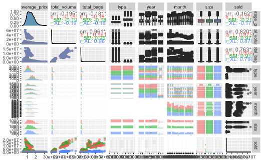

```r
# look for correlations that might suggest some significant relationship between target variable `average_price` and explanatory variables
avocado_tidy %>%
  ggpairs(aes(color = size, alpha = 0.5),
          progress = FALSE)
```

`type` and `month` are showing some separation in box plots against `average_price`, that is indicating some significant association

Let’s look at two model taking each of the two explanatory variables in separatelly and compare how them

# Model 1

## Model 1a

### R-squared: 0.3774

### Residual standard error: 0.3177

```
`arrange_()` is deprecated as of dplyr 0.7.0.
Please use `arrange()` instead.
See vignette('programming') for more help
```

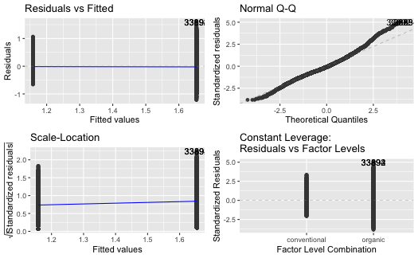

```r
mod1a <- lm(average_price ~ type, data = avocado_tidy)
autoplot(mod1a)
```

```r
summary(mod1a)
```

```
Call:
lm(formula = average_price ~ type, data = avocado_tidy)

Residuals:
     Min       1Q   Median       3Q      Max
-1.21337 -0.20337 -0.02867  0.18663  1.59663

Coefficients:
            Estimate Std. Error t value Pr(>|t|)
(Intercept) 1.158670   0.002151   538.8   <2e-16 ***
typeorganic 0.494704   0.003036   162.9   <2e-16 ***
---
Signif. codes:  0 ‘***’ 0.001 ‘**’ 0.01 ‘*’ 0.05 ‘.’ 0.1 ‘ ’ 1

Residual standard error: 0.3177 on 43798 degrees of freedom
Multiple R-squared:  0.3774,    Adjusted R-squared:  0.3773
F-statistic: 2.654e+04 on 1 and 43798 DF,  p-value: < 2.2e-16
```

## Model 1b

### Multiple R-squared: 0.05652

### Residual standard error: 0.3912

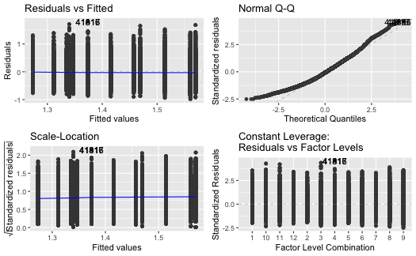

```r
mod1b <- lm(average_price ~ month, data = avocado_tidy)
autoplot(mod1b)
```

```r
summary(mod1b)
```

```
Call:
lm(formula = average_price ~ month, data = avocado_tidy)

Residuals:
     Min       1Q   Median       3Q      Max
-0.98056 -0.29728 -0.02998  0.25272  1.79610

Coefficients:
             Estimate Std. Error t value Pr(>|t|)
(Intercept)  1.311551   0.005718 229.377  < 2e-16 ***
month2      -0.038109   0.008341  -4.569 4.92e-06 ***
month3       0.028186   0.008246   3.418 0.000631 ***
month4       0.062346   0.008824   7.065 1.63e-12 ***
month5       0.035728   0.008645   4.133 3.59e-05 ***
month6       0.103855   0.009057  11.467  < 2e-16 ***
month7       0.145706   0.008643  16.858  < 2e-16 ***
month8       0.202524   0.008809  22.992  < 2e-16 ***
month9       0.249010   0.009059  27.487  < 2e-16 ***
month10      0.258424   0.008647  29.885  < 2e-16 ***
month11      0.157618   0.008818  17.875  < 2e-16 ***
month12      0.023616   0.008870   2.662 0.007764 **
---
Signif. codes:  0 ‘***’ 0.001 ‘**’ 0.01 ‘*’ 0.05 ‘.’ 0.1 ‘ ’ 1

Residual standard error: 0.3912 on 43788 degrees of freedom
Multiple R-squared:  0.05652,   Adjusted R-squared:  0.05629
F-statistic: 238.5 on 11 and 43788 DF,  p-value: < 2.2e-16
```

### Mod1a is definitelly better

No other variable is standing out really, let’s try an automated model building

# Model 2

### forward selection

```r
mod2_forward <- regsubsets(average_price ~ .,
                           data = avocado_tidy,
                           nvmax = 9, # intercept + number of columns
                           method = "forward")

summary(mod2_forward)
```

```
Subset selection object
Call: regsubsets.formula(average_price ~ ., data = avocado_tidy, nvmax = 9,
    method = "forward")
20 Variables  (and intercept)
             Forced in Forced out
total_volume     FALSE      FALSE
total_bags       FALSE      FALSE
typeorganic      FALSE      FALSE
year2016         FALSE      FALSE
year2017         FALSE      FALSE
year2018         FALSE      FALSE
month2           FALSE      FALSE
month3           FALSE      FALSE
month4           FALSE      FALSE
month5           FALSE      FALSE
month6           FALSE      FALSE
month7           FALSE      FALSE
month8           FALSE      FALSE
month9           FALSE      FALSE
month10          FALSE      FALSE
month11          FALSE      FALSE
month12          FALSE      FALSE
sizesize_SM      FALSE      FALSE
sizesize_XL      FALSE      FALSE
sold             FALSE      FALSE
1 subsets of each size up to 9
Selection Algorithm: forward
         total_volume total_bags typeorganic year2016 year2017 year2018 month2 month3 month4 month5 month6 month7
1  ( 1 ) " "          " "        "*"         " "      " "      " "      " "    " "    " "    " "    " "    " "
2  ( 1 ) " "          " "        "*"         " "      "*"      " "      " "    " "    " "    " "    " "    " "
3  ( 1 ) " "          " "        "*"         " "      "*"      " "      " "    " "    " "    " "    " "    " "
4  ( 1 ) " "          " "        "*"         " "      "*"      " "      " "    " "    " "    " "    " "    " "
5  ( 1 ) " "          " "        "*"         " "      "*"      " "      " "    " "    " "    " "    " "    " "
6  ( 1 ) " "          " "        "*"         " "      "*"      " "      " "    " "    " "    " "    " "    " "
7  ( 1 ) " "          " "        "*"         " "      "*"      " "      " "    " "    " "    " "    " "    "*"
8  ( 1 ) " "          " "        "*"         " "      "*"      " "      " "    " "    " "    " "    "*"    "*"
9  ( 1 ) " "          " "        "*"         "*"      "*"      " "      " "    " "    " "    " "    "*"    "*"
         month8 month9 month10 month11 month12 sizesize_SM sizesize_XL sold
1  ( 1 ) " "    " "    " "     " "     " "     " "         " "         " "
2  ( 1 ) " "    " "    " "     " "     " "     " "         " "         " "
3  ( 1 ) " "    " "    "*"     " "     " "     " "         " "         " "
4  ( 1 ) " "    "*"    "*"     " "     " "     " "         " "         " "
5  ( 1 ) "*"    "*"    "*"     " "     " "     " "         " "         " "
6  ( 1 ) "*"    "*"    "*"     "*"     " "     " "         " "         " "
7  ( 1 ) "*"    "*"    "*"     "*"     " "     " "         " "         " "
8  ( 1 ) "*"    "*"    "*"     "*"     " "     " "         " "         " "
9  ( 1 ) "*"    "*"    "*"     "*"     " "     " "         " "         " "
```

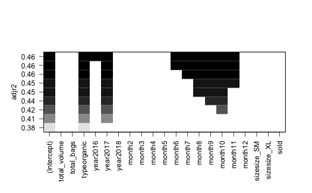

```r
plot(mod2_forward, scale = "adjr2")
```

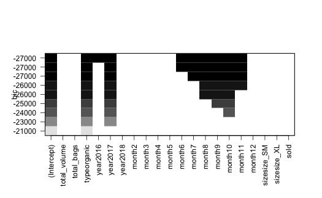

```r
plot(mod2_forward)
```

Nope, unfortunately, this method got rid of some of the levels of categorical (factor) variables. Back to manual model building.. From the automated model it seems like year and month variables might be explaining significantly the target variable, let’s try adding these

# Model 3

## Model 3a

### R-squared: 0.411

### Residual standard error: 0.309

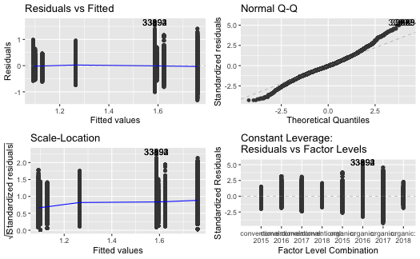

```r
mod3a <- lm(average_price ~ type + year, data = avocado_tidy)
autoplot(mod3a)
```

```r
summary(mod3a)
```

```
Call:
lm(formula = average_price ~ type + year, data = avocado_tidy)

Residuals:
    Min      1Q  Median      3Q     Max
-1.3203 -0.1870 -0.0152  0.1830  1.6630

Coefficients:
             Estimate Std. Error t value Pr(>|t|)
(Intercept)  1.129045   0.003042 371.149  < 2e-16 ***
typeorganic  0.495086   0.002953 167.632  < 2e-16 ***
year2016    -0.037087   0.003766  -9.848  < 2e-16 ***
year2017     0.136158   0.003743  36.379  < 2e-16 ***
year2018    -0.029074   0.006176  -4.708 2.51e-06 ***
---
Signif. codes:  0 ‘***’ 0.001 ‘**’ 0.01 ‘*’ 0.05 ‘.’ 0.1 ‘ ’ 1

Residual standard error: 0.309 on 43795 degrees of freedom
Multiple R-squared:  0.411, Adjusted R-squared:  0.4109
F-statistic:  7639 on 4 and 43795 DF,  p-value: < 2.2e-16
```

## Model 3b

### R-squared: 0.4353

Residual standard error: 0.3026

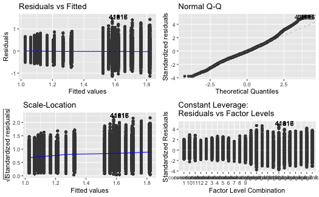

```r
mod3b <- lm(average_price ~ type + month, data = avocado_tidy)
autoplot(mod3b)
```

```r
summary(mod3b)
```

```
Call:
lm(formula = average_price ~ type + month, data = avocado_tidy)

Residuals:
     Min       1Q   Median       3Q      Max
-1.14125 -0.19648 -0.02125  0.18701  1.55066

Coefficients:
             Estimate Std. Error t value Pr(>|t|)
(Intercept)  1.061785   0.004657 227.977  < 2e-16 ***
typeorganic  0.495720   0.002892 171.391  < 2e-16 ***
month2      -0.035307   0.006453  -5.471 4.49e-08 ***
month3       0.023746   0.006379   3.722 0.000198 ***
month4       0.061838   0.006827   9.058  < 2e-16 ***
month5       0.041926   0.006688   6.268 3.68e-10 ***
month6       0.104323   0.007006  14.890  < 2e-16 ***
month7       0.144346   0.006687  21.587  < 2e-16 ***
month8       0.205740   0.006815  30.191  < 2e-16 ***
month9       0.257875   0.007009  36.794  < 2e-16 ***
month10      0.263194   0.006690  39.342  < 2e-16 ***
month11      0.151205   0.006822  22.165  < 2e-16 ***
month12      0.024852   0.006862   3.621 0.000293 ***
---
Signif. codes:  0 ‘***’ 0.001 ‘**’ 0.01 ‘*’ 0.05 ‘.’ 0.1 ‘ ’ 1

Residual standard error: 0.3026 on 43787 degrees of freedom
Multiple R-squared:  0.4353,    Adjusted R-squared:  0.4352
F-statistic:  2813 on 12 and 43787 DF,  p-value: < 2.2e-16
```

Mod3b is better! Does it explain more variance in the `average_price` than mod1a though? -> ANOVA

```r
anova(mod1a, mod3b)
```

```
Analysis of Variance Table

Model 1: average_price ~ type
Model 2: average_price ~ type + month
  Res.Df    RSS Df Sum of Sq      F    Pr(>F)
1  43798 4421.6
2  43787 4009.9 11    411.68 408.67 < 2.2e-16 ***
---
Signif. codes:  0 ‘***’ 0.001 ‘**’ 0.01 ‘*’ 0.05 ‘.’ 0.1 ‘ ’ 1
```

p-value 2.2e-16 *** -> significant! model including both explanatory variables is better

### so far, my best model is mod3b

let’s try adding both `year` and `month` too, and then also their interaction

# Model 4

## Model 4a

### R-squared: 0.469

### Residual standard error: 0.2935

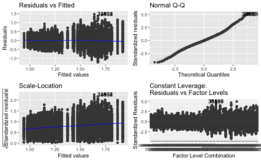

```r
mod4a <- lm(average_price ~ type + month + year, data = avocado_tidy)
autoplot(mod4a)
```

```r
summary(mod4a)
```

```
Call:
lm(formula = average_price ~ type + month + year, data = avocado_tidy)

Residuals:
     Min       1Q   Median       3Q      Max
-1.23452 -0.18772 -0.01239  0.17776  1.50334

Coefficients:
             Estimate Std. Error t value Pr(>|t|)
(Intercept)  1.014525   0.005180 195.850  < 2e-16 ***
typeorganic  0.496222   0.002805 176.912  < 2e-16 ***
month2      -0.035396   0.006260  -5.654 1.58e-08 ***
month3       0.026737   0.006189   4.320 1.57e-05 ***
month4       0.068653   0.006755  10.163  < 2e-16 ***
month5       0.063179   0.006627   9.534  < 2e-16 ***
month6       0.117752   0.006926  17.003  < 2e-16 ***
month7       0.157075   0.006621  23.723  < 2e-16 ***
month8       0.222088   0.006746  32.924  < 2e-16 ***
month9       0.273377   0.006928  39.460  < 2e-16 ***
month10      0.274456   0.006624  41.433  < 2e-16 ***
month11      0.166595   0.006753  24.670  < 2e-16 ***
month12      0.030705   0.006789   4.522 6.13e-06 ***
year2016    -0.038546   0.003581 -10.764  < 2e-16 ***
year2017     0.137038   0.003562  38.468  < 2e-16 ***
year2018     0.087932   0.006391  13.759  < 2e-16 ***
---
Signif. codes:  0 ‘***’ 0.001 ‘**’ 0.01 ‘*’ 0.05 ‘.’ 0.1 ‘ ’ 1

Residual standard error: 0.2935 on 43784 degrees of freedom
Multiple R-squared:  0.469, Adjusted R-squared:  0.4688
F-statistic:  2578 on 15 and 43784 DF,  p-value: < 2.2e-16
```

## Model 4b

### R-squared: 0.5048

### Residual standard error: 0.2835

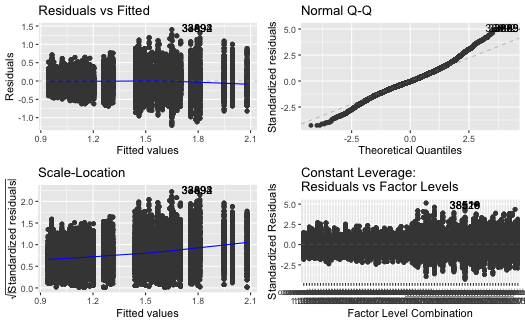

```r
mod4b <- lm(average_price ~ type + month:year, data = avocado_tidy)
autoplot(mod4b)
```

```r
summary(mod4b)
```

```
Call:
lm(formula = average_price ~ type + month:year, data = avocado_tidy)

Residuals:
     Min       1Q   Median       3Q      Max
-1.20940 -0.17022 -0.01295  0.16924  1.45563

Coefficients: (10 not defined because of singularities)
                  Estimate Std. Error t value Pr(>|t|)
(Intercept)       1.094998   0.009022 121.371  < 2e-16 ***
typeorganic       0.497360   0.002710 183.537  < 2e-16 ***
month1:year2015   0.025019   0.012422   2.014 0.044004 *
month2:year2015  -0.016927   0.012544  -1.349 0.177206
month3:year2015   0.017628   0.012014   1.467 0.142297
month4:year2015   0.037861   0.012473   3.035 0.002404 **
month5:year2015   0.003744   0.011830   0.316 0.751649
month6:year2015   0.057869   0.012535   4.617 3.91e-06 ***
month7:year2015   0.059229   0.012464   4.752 2.02e-06 ***
month8:year2015   0.106000   0.011982   8.847  < 2e-16 ***
month9:year2015   0.107954   0.012517   8.625  < 2e-16 ***
month10:year2015  0.044772   0.012490   3.585 0.000338 ***
month11:year2015 -0.014231   0.011938  -1.192 0.233210
month12:year2015 -0.027835   0.012508  -2.225 0.026063 *
month1:year2016  -0.104819   0.011944  -8.776  < 2e-16 ***
month2:year2016  -0.098788   0.012544  -7.875 3.48e-15 ***
month3:year2016  -0.120096   0.012499  -9.608  < 2e-16 ***
month4:year2016  -0.151599   0.012508 -12.120  < 2e-16 ***
month5:year2016  -0.138673   0.011950 -11.604  < 2e-16 ***
month6:year2016  -0.057286   0.012580  -4.554 5.29e-06 ***
month7:year2016   0.055015   0.011877   4.632 3.63e-06 ***
month8:year2016   0.066289   0.012388   5.351 8.80e-08 ***
month9:year2016   0.085643   0.012491   6.857 7.14e-12 ***
month10:year2016  0.202015   0.011931  16.931  < 2e-16 ***
month11:year2016  0.217855   0.012508  17.417  < 2e-16 ***
month12:year2016 -0.021919   0.012636  -1.735 0.082823 .
month1:year2017  -0.072763   0.011889  -6.120 9.42e-10 ***
month2:year2017  -0.131041   0.012473 -10.506  < 2e-16 ***
month3:year2017   0.057047   0.012526   4.554 5.27e-06 ***
month4:year2017   0.165064   0.011913  13.856  < 2e-16 ***
month5:year2017   0.191908   0.012517  15.332  < 2e-16 ***
```

[output cut: 10 more lines]

```
month4:year2018         NA         NA      NA       NA
month5:year2018         NA         NA      NA       NA
month6:year2018         NA         NA      NA       NA
month7:year2018         NA         NA      NA       NA
month8:year2018         NA         NA      NA       NA
month9:year2018         NA         NA      NA       NA
month10:year2018        NA         NA      NA       NA
month11:year2018        NA         NA      NA       NA
month12:year2018        NA         NA      NA       NA
---
Signif. codes:  0 ‘***’ 0.001 ‘**’ 0.01 ‘*’ 0.05 ‘.’ 0.1 ‘ ’ 1

Residual standard error: 0.2835 on 43760 degrees of freedom
Multiple R-squared:  0.5048,    Adjusted R-squared:  0.5044
F-statistic:  1144 on 39 and 43760 DF,  p-value: < 2.2e-16
```

### mod4b is winning now, let’s look at remaining predictors, i.e. all predictors not yet in the model mod4b

```r
avocado_tidy_remaining_resid <- avocado_tidy %>%
  add_residuals(mod4b) %>%
  select(-c("average_price", "type", "month", "year"))
```

```
prediction from a rank-deficient fit may be misleading
```

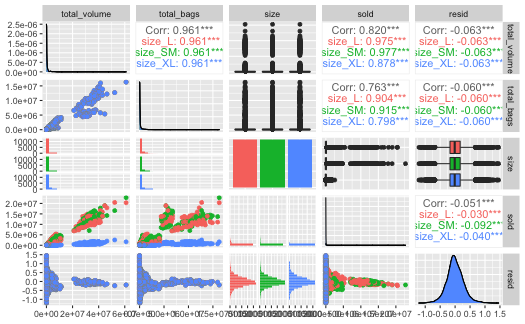

```r
avocado_tidy_remaining_resid %>%
  ggpairs(aes(color = size),
          progress = FALSE)
```

# Model 5

## Model 5a

### R-squared: 0.5067

### Residual standard error: 0.2829

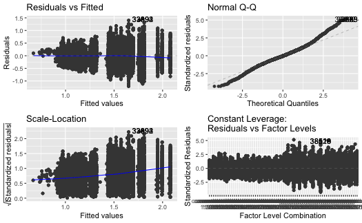

```r
mod5a <- lm(average_price ~ type + month:year + total_bags, data = avocado_tidy)
autoplot(mod5a)
```

```r
summary(mod5a)
```

```
Call:
lm(formula = average_price ~ type + month:year + total_bags,
    data = avocado_tidy)

Residuals:
     Min       1Q   Median       3Q      Max
-1.20966 -0.16932 -0.01089  0.16860  1.45480

Coefficients: (10 not defined because of singularities)
                   Estimate Std. Error t value Pr(>|t|)
(Intercept)       1.106e+00  9.046e-03 122.286  < 2e-16 ***
typeorganic       4.894e-01  2.774e-03 176.398  < 2e-16 ***
total_bags       -1.877e-08  1.446e-09 -12.977  < 2e-16 ***
month1:year2015   2.032e-02  1.240e-02   1.638  0.10141
month2:year2015  -2.165e-02  1.253e-02  -1.728  0.08396 .
month3:year2015   1.280e-02  1.200e-02   1.067  0.28615
month4:year2015   3.307e-02  1.245e-02   2.655  0.00792 **
month5:year2015  -4.029e-04  1.181e-02  -0.034  0.97279
month6:year2015   5.419e-02  1.251e-02   4.330 1.49e-05 ***
month7:year2015   5.486e-02  1.245e-02   4.408 1.05e-05 ***
month8:year2015   1.013e-01  1.196e-02   8.467  < 2e-16 ***
month9:year2015   1.035e-01  1.250e-02   8.278  < 2e-16 ***
month10:year2015  3.998e-02  1.247e-02   3.206  0.00135 **
month11:year2015 -1.871e-02  1.192e-02  -1.569  0.11654
month12:year2015 -3.183e-02  1.249e-02  -2.549  0.01080 *
month1:year2016  -1.074e-01  1.192e-02  -9.006  < 2e-16 ***
month2:year2016  -1.005e-01  1.252e-02  -8.026 1.03e-15 ***
month3:year2016  -1.231e-01  1.248e-02  -9.865  < 2e-16 ***
month4:year2016  -1.534e-01  1.248e-02 -12.285  < 2e-16 ***
month5:year2016  -1.397e-01  1.193e-02 -11.711  < 2e-16 ***
month6:year2016  -5.949e-02  1.256e-02  -4.738 2.17e-06 ***
month7:year2016   5.328e-02  1.185e-02   4.495 6.99e-06 ***
month8:year2016   6.460e-02  1.237e-02   5.224 1.76e-07 ***
month9:year2016   8.336e-02  1.247e-02   6.686 2.32e-11 ***
month10:year2016  1.998e-01  1.191e-02  16.773  < 2e-16 ***
month11:year2016  2.149e-01  1.249e-02  17.214  < 2e-16 ***
month12:year2016 -2.347e-02  1.261e-02  -1.861  0.06278 .
month1:year2017  -7.431e-02  1.187e-02  -6.262 3.83e-10 ***
month2:year2017  -1.318e-01  1.245e-02 -10.587  < 2e-16 ***
month3:year2017   5.527e-02  1.250e-02   4.421 9.85e-06 ***
```

[output cut: 12 more lines]

```
month4:year2018          NA         NA      NA       NA
month5:year2018          NA         NA      NA       NA
month6:year2018          NA         NA      NA       NA
month7:year2018          NA         NA      NA       NA
month8:year2018          NA         NA      NA       NA
month9:year2018          NA         NA      NA       NA
month10:year2018         NA         NA      NA       NA
month11:year2018         NA         NA      NA       NA
month12:year2018         NA         NA      NA       NA
---
Signif. codes:  0 ‘***’ 0.001 ‘**’ 0.01 ‘*’ 0.05 ‘.’ 0.1 ‘ ’ 1

Residual standard error: 0.2829 on 43759 degrees of freedom
Multiple R-squared:  0.5067,    Adjusted R-squared:  0.5063
F-statistic:  1124 on 40 and 43759 DF,  p-value: < 2.2e-16
```

## Model 5b

### R-squared: 0.5062

### Residual standard error: 0.2831

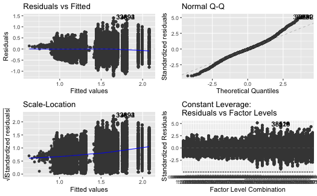

```r
mod5b <- lm(average_price ~ type + month:year + sold, data = avocado_tidy)
autoplot(mod5b)
```

```r
summary(mod5b)
```

```
Call:
lm(formula = average_price ~ type + month:year + sold, data = avocado_tidy)

Residuals:
     Min       1Q   Median       3Q      Max
-1.20926 -0.16969 -0.01134  0.16850  1.45624

Coefficients: (10 not defined because of singularities)
                   Estimate Std. Error t value Pr(>|t|)
(Intercept)       1.101e+00  9.026e-03 121.977  < 2e-16 ***
typeorganic       4.915e-01  2.758e-03 178.218  < 2e-16 ***
sold             -1.486e-08  1.357e-09 -10.946  < 2e-16 ***
month1:year2015   2.524e-02  1.240e-02   2.035 0.041861 *
month2:year2015  -1.634e-02  1.253e-02  -1.304 0.192138
month3:year2015   1.760e-02  1.200e-02   1.467 0.142487
month4:year2015   3.788e-02  1.246e-02   3.041 0.002362 **
month5:year2015   4.843e-03  1.181e-02   0.410 0.681856
month6:year2015   5.881e-02  1.252e-02   4.698 2.63e-06 ***
month7:year2015   5.942e-02  1.245e-02   4.774 1.82e-06 ***
month8:year2015   1.061e-01  1.197e-02   8.866  < 2e-16 ***
month9:year2015   1.082e-01  1.250e-02   8.657  < 2e-16 ***
month10:year2015  4.453e-02  1.247e-02   3.570 0.000358 ***
month11:year2015 -1.465e-02  1.192e-02  -1.229 0.218979
month12:year2015 -2.824e-02  1.249e-02  -2.261 0.023752 *
month1:year2016  -1.047e-01  1.193e-02  -8.777  < 2e-16 ***
month2:year2016  -9.812e-02  1.253e-02  -7.832 4.89e-15 ***
month3:year2016  -1.204e-01  1.248e-02  -9.649  < 2e-16 ***
month4:year2016  -1.512e-01  1.249e-02 -12.107  < 2e-16 ***
month5:year2016  -1.376e-01  1.193e-02 -11.528  < 2e-16 ***
month6:year2016  -5.730e-02  1.256e-02  -4.561 5.11e-06 ***
month7:year2016   5.487e-02  1.186e-02   4.626 3.74e-06 ***
month8:year2016   6.632e-02  1.237e-02   5.360 8.35e-08 ***
month9:year2016   8.525e-02  1.247e-02   6.835 8.32e-12 ***
month10:year2016  2.014e-01  1.192e-02  16.901  < 2e-16 ***
month11:year2016  2.170e-01  1.249e-02  17.375  < 2e-16 ***
month12:year2016 -2.218e-02  1.262e-02  -1.758 0.078788 .
month1:year2017  -7.277e-02  1.187e-02  -6.129 8.91e-10 ***
month2:year2017  -1.305e-01  1.246e-02 -10.476  < 2e-16 ***
month3:year2017   5.672e-02  1.251e-02   4.535 5.79e-06 ***
month4:year2017   1.647e-01  1.190e-02  13.845  < 2e-16 ***
```

[output cut: 11 more lines]

```
month4:year2018          NA         NA      NA       NA
month5:year2018          NA         NA      NA       NA
month6:year2018          NA         NA      NA       NA
month7:year2018          NA         NA      NA       NA
month8:year2018          NA         NA      NA       NA
month9:year2018          NA         NA      NA       NA
month10:year2018         NA         NA      NA       NA
month11:year2018         NA         NA      NA       NA
month12:year2018         NA         NA      NA       NA
---
Signif. codes:  0 ‘***’ 0.001 ‘**’ 0.01 ‘*’ 0.05 ‘.’ 0.1 ‘ ’ 1

Residual standard error: 0.2831 on 43759 degrees of freedom
Multiple R-squared:  0.5062,    Adjusted R-squared:  0.5057
F-statistic:  1121 on 40 and 43759 DF,  p-value: < 2.2e-16
```

mod5a is slightly better

### check the model mod5a explains more variance then mod4b -> ANOVA (all good!)

p-value 2.2e-16 *** - significant!

```r
anova(mod4b, mod5a)
```

```
Analysis of Variance Table

Model 1: average_price ~ type + month:year
Model 2: average_price ~ type + month:year + total_bags
  Res.Df    RSS Df Sum of Sq      F    Pr(>F)
1  43760 3516.4
2  43759 3502.9  1     13.48 168.39 < 2.2e-16 ***
---
Signif. codes:  0 ‘***’ 0.001 ‘**’ 0.01 ‘*’ 0.05 ‘.’ 0.1 ‘ ’ 1
```

### let’s look at the mentioned goodnes of fit measures in mod4b and mod5a

#### mod4b: adj.r.squared 0.5043912, BIC 14264.55

#### mod5a: adj.r.squared 0.5062798, BIC 14107.01 <- better!

```r
glance(mod4b)
```

| r.squared | adj.r.squared | sigma | statistic | p.value | df | logLik | AIC | BIC | deviance | df.residual | nobs |
| --- | --- | --- | --- | --- | --- | --- | --- | --- | --- | --- | --- |
| 0.5048325 | 0.5043912 | 0.2834707 | 1143.952 | 0 | 39 | -6913.185 | 13908.37 | 14264.55 | 3516.363 | 43760 | 43800 |

```r
glance(mod5a)
```

| r.squared | adj.r.squared | sigma | statistic | p.value | df | logLik | AIC | BIC | deviance | df.residual | nobs |
| --- | --- | --- | --- | --- | --- | --- | --- | --- | --- | --- | --- |
| 0.5067307 | 0.5062798 | 0.2829301 | 1123.83 | 0 | 40 | -6829.071 | 13742.14 | 14107.01 | 3502.883 | 43759 | 43800 |

### mod5a is so far the best, and not over-fitted yet, so let’s also try adding `sold`

# Model 6

## Model 6

### R-squared: 0.5068

### Residual standard error: 0.2829

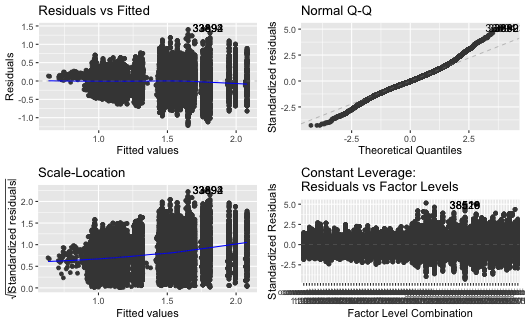

```r
mod6 <- lm(average_price ~ type + month:year + total_bags + sold, data = avocado_tidy)
autoplot(mod6)
```

```r
summary(mod6)
```

```
Call:
lm(formula = average_price ~ type + month:year + total_bags +
    sold, data = avocado_tidy)

Residuals:
     Min       1Q   Median       3Q      Max
-1.20959 -0.16938 -0.01068  0.16853  1.45508

Coefficients: (10 not defined because of singularities)
                   Estimate Std. Error t value Pr(>|t|)
(Intercept)       1.106e+00  9.047e-03 122.241  < 2e-16 ***
typeorganic       4.892e-01  2.776e-03 176.224  < 2e-16 ***
total_bags       -1.585e-08  2.209e-09  -7.176 7.30e-13 ***
sold             -3.613e-09  2.072e-09  -1.743  0.08127 .
month1:year2015   2.110e-02  1.241e-02   1.700  0.08909 .
month2:year2015  -2.077e-02  1.253e-02  -1.657  0.09752 .
month3:year2015   1.354e-02  1.200e-02   1.128  0.25942
month4:year2015   3.382e-02  1.246e-02   2.714  0.00665 **
month5:year2015   5.080e-04  1.182e-02   0.043  0.96573
month6:year2015   5.499e-02  1.252e-02   4.391 1.13e-05 ***
month7:year2015   5.558e-02  1.245e-02   4.464 8.08e-06 ***
month8:year2015   1.021e-01  1.197e-02   8.524  < 2e-16 ***
month9:year2015   1.042e-01  1.251e-02   8.334  < 2e-16 ***
month10:year2015  4.067e-02  1.248e-02   3.259  0.00112 **
month11:year2015 -1.812e-02  1.192e-02  -1.519  0.12870
month12:year2015 -3.131e-02  1.249e-02  -2.507  0.01219 *
month1:year2016  -1.069e-01  1.192e-02  -8.969  < 2e-16 ***
month2:year2016  -1.001e-01  1.252e-02  -7.990 1.38e-15 ***
month3:year2016  -1.227e-01  1.248e-02  -9.834  < 2e-16 ***
month4:year2016  -1.530e-01  1.249e-02 -12.254  < 2e-16 ***
month5:year2016  -1.393e-01  1.193e-02 -11.673  < 2e-16 ***
month6:year2016  -5.915e-02  1.256e-02  -4.710 2.48e-06 ***
month7:year2016   5.352e-02  1.186e-02   4.514 6.38e-06 ***
month8:year2016   6.487e-02  1.237e-02   5.246 1.57e-07 ***
month9:year2016   8.362e-02  1.247e-02   6.706 2.02e-11 ***
month10:year2016  2.000e-01  1.191e-02  16.789  < 2e-16 ***
month11:year2016  2.152e-01  1.249e-02  17.234  < 2e-16 ***
month12:year2016 -2.329e-02  1.261e-02  -1.847  0.06479 .
month1:year2017  -7.407e-02  1.187e-02  -6.242 4.37e-10 ***
month2:year2017  -1.316e-01  1.245e-02 -10.567  < 2e-16 ***
```

[output cut: 13 more lines]

```
month4:year2018          NA         NA      NA       NA
month5:year2018          NA         NA      NA       NA
month6:year2018          NA         NA      NA       NA
month7:year2018          NA         NA      NA       NA
month8:year2018          NA         NA      NA       NA
month9:year2018          NA         NA      NA       NA
month10:year2018         NA         NA      NA       NA
month11:year2018         NA         NA      NA       NA
month12:year2018         NA         NA      NA       NA
---
Signif. codes:  0 ‘***’ 0.001 ‘**’ 0.01 ‘*’ 0.05 ‘.’ 0.1 ‘ ’ 1

Residual standard error: 0.2829 on 43758 degrees of freedom
Multiple R-squared:  0.5068,    Adjusted R-squared:  0.5063
F-statistic:  1097 on 41 and 43758 DF,  p-value: < 2.2e-16
```

### check the model mod6 explains more variance then mod5a -> ANOVA (nope!)

p-value 0.08127 - not significant! We failed to reject H0. Models are explaining the same amount of variance in price of avocados. I’m gonna stick with simpler model mod5a.

```r
anova(mod5a, mod6)
```

```
Analysis of Variance Table

Model 1: average_price ~ type + month:year + total_bags
Model 2: average_price ~ type + month:year + total_bags + sold
  Res.Df    RSS Df Sum of Sq      F  Pr(>F)
1  43759 3502.9
2  43758 3502.6  1    0.2433 3.0396 0.08127 .
---
Signif. codes:  0 ‘***’ 0.001 ‘**’ 0.01 ‘*’ 0.05 ‘.’ 0.1 ‘ ’ 1
```

### Predict test data, based on model developed on training data

```r
# need to do just a slight adjustment to the data, create the month variable so it fits the model, and change categorical variables to factors
test_adjusted <- test %>%
  mutate(
    month = month(date) %>% as.factor()
  ) %>%
  mutate(
    year = as.factor(year),
    type = as.factor(type)
  )
```

```r
# predict test data, based on model from training data (winner was mod5a)
predictions_test <- predict(mod5a, newdata = test_adjusted)
```

```
prediction from a rank-deficient fit may be misleading
```

```r
# calculate the mean squared error on my TEST data
mean((predictions_test - test_adjusted$average_price)^2)
```

```
[1] 0.07699686
```

```r
# find the mean squared error of the predictions on my TRAIN data
mean((predictions_test - train$average_price)^2)
```

```
longer object length is not a multiple of shorter object length
```

```
[1] 0.2464535
```

```r
# r^2 for mod5a used on test data
test_check <- lm(average_price ~ type + month:year + total_bags, data = test_adjusted)
summary(test_check)
```

```
Call:
lm(formula = average_price ~ type + month:year + total_bags,
    data = test_adjusted)

Residuals:
     Min       1Q   Median       3Q      Max
-1.02677 -0.17065 -0.00954  0.16798  1.24314

Coefficients: (10 not defined because of singularities)
                   Estimate Std. Error t value Pr(>|t|)
(Intercept)       1.076e+00  2.895e-02  37.165  < 2e-16 ***
typeorganic       4.831e-01  9.437e-03  51.193  < 2e-16 ***
total_bags       -1.454e-08  4.396e-09  -3.307 0.000953 ***
month1:year2015   3.001e-02  4.306e-02   0.697 0.485915
month2:year2015   1.203e-02  4.109e-02   0.293 0.769721
month3:year2015   4.838e-02  3.767e-02   1.284 0.199073
month4:year2015   7.748e-02  4.214e-02   1.839 0.066051 .
month5:year2015   1.651e-02  4.011e-02   0.412 0.680669
month6:year2015   7.306e-02  4.122e-02   1.773 0.076389 .
month7:year2015   1.235e-01  4.228e-02   2.922 0.003494 **
month8:year2015   1.107e-01  3.800e-02   2.914 0.003591 **
month9:year2015   1.227e-01  4.147e-02   2.960 0.003097 **
month10:year2015  9.152e-02  4.185e-02   2.187 0.028830 *
month11:year2015  1.860e-02  3.850e-02   0.483 0.629057
month12:year2015 -5.249e-02  4.172e-02  -1.258 0.208399
month1:year2016  -6.973e-02  3.841e-02  -1.815 0.069559 .
month2:year2016  -1.078e-01  4.108e-02  -2.624 0.008733 **
month3:year2016  -8.562e-02  4.169e-02  -2.054 0.040081 *
month4:year2016  -5.655e-02  4.158e-02  -1.360 0.173855
month5:year2016  -1.346e-01  3.834e-02  -3.510 0.000454 ***
month6:year2016  -4.258e-02  4.059e-02  -1.049 0.294264
month7:year2016   9.833e-02  3.930e-02   2.502 0.012395 *
month8:year2016   1.015e-01  4.373e-02   2.321 0.020339 *
month9:year2016   1.088e-01  4.184e-02   2.601 0.009322 **
month10:year2016  2.839e-01  3.858e-02   7.359 2.29e-13 ***
month11:year2016  1.855e-01  4.159e-02   4.461 8.42e-06 ***
month12:year2016 -1.907e-02  3.998e-02  -0.477 0.633448
month1:year2017  -7.711e-03  3.912e-02  -0.197 0.843748
month2:year2017  -8.859e-02  4.211e-02  -2.104 0.035461 *
month3:year2017   7.771e-02  4.131e-02   1.881 0.060023 .
```

[output cut: 12 more lines]

```
month4:year2018          NA         NA      NA       NA
month5:year2018          NA         NA      NA       NA
month6:year2018          NA         NA      NA       NA
month7:year2018          NA         NA      NA       NA
month8:year2018          NA         NA      NA       NA
month9:year2018          NA         NA      NA       NA
month10:year2018         NA         NA      NA       NA
month11:year2018         NA         NA      NA       NA
month12:year2018         NA         NA      NA       NA
---
Signif. codes:  0 ‘***’ 0.001 ‘**’ 0.01 ‘*’ 0.05 ‘.’ 0.1 ‘ ’ 1

Residual standard error: 0.2775 on 3608 degrees of freedom
Multiple R-squared:  0.5306,    Adjusted R-squared:  0.5254
F-statistic: 101.9 on 40 and 3608 DF,  p-value: < 2.2e-16
```

(MSE - mean squared error: the average squared difference between the estimated values and the actual value)

### mod5a on test data: R-squared 0.5306, Residual standard error 0.2775

## Conclusion: I randomly splitted the avocado dataset into two datasets - training (made of 80% of the data), and testing (remaining 20%).

### Final model: *average_price ~ type + month:year + total_bags*